# Kimbe Bay Coral Reef Predator Fish Diversity Anslysis

Ben Cresswell

05 November, 2021

Rmd created: 2.7.2021 Last edit: 31 Aug 2021 BJC Last edit: 26 Oct 2021 BJC

# Introduction

# Packages and housekeeping

# Data import and wrangling

## Diversity data wrangling script

Generates a master-diversity data frame which includes diversity metrics and a species matrix

# 1. Species Richness

# Basic data exploration

## Data overview

Check how the data are distributed across the different reefs and reef types

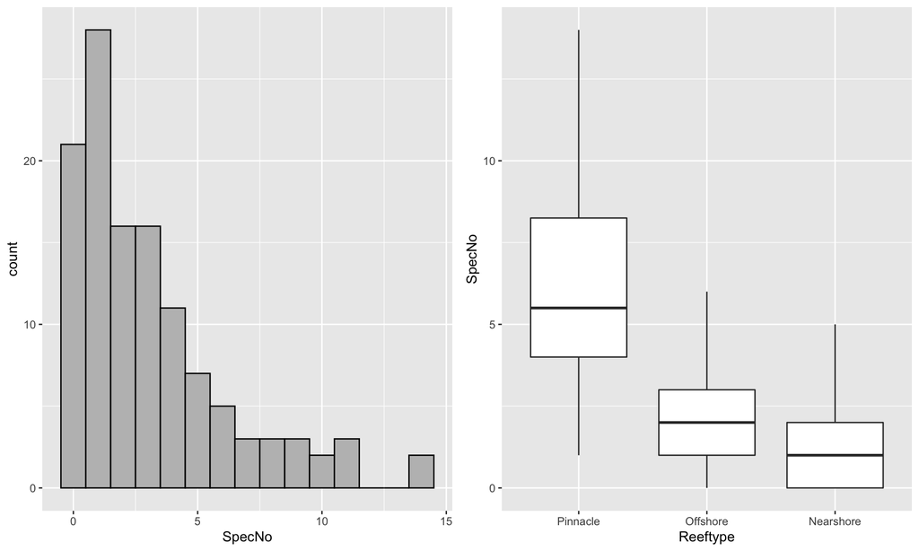

```r
# Histogram
srhist <- ggplot(preddiv, aes(x=SpecNo)) +
  geom_histogram(binwidth=1, color="black", fill="grey") # Count data and looks poisson distributed

# Boxplot - by reeftype
srbox <- ggplot(preddiv, aes(x=Reeftype, y=SpecNo))+
  geom_boxplot()

grid.arrange(srhist, srbox, ncol=2)
```

- Count data: will start with Poisson and move to neg binom if doesn’t work

## Random effects

- Investigate random effects (added post ML course Oct 2021) (Note: AIC comparison with fixed effect models included below)

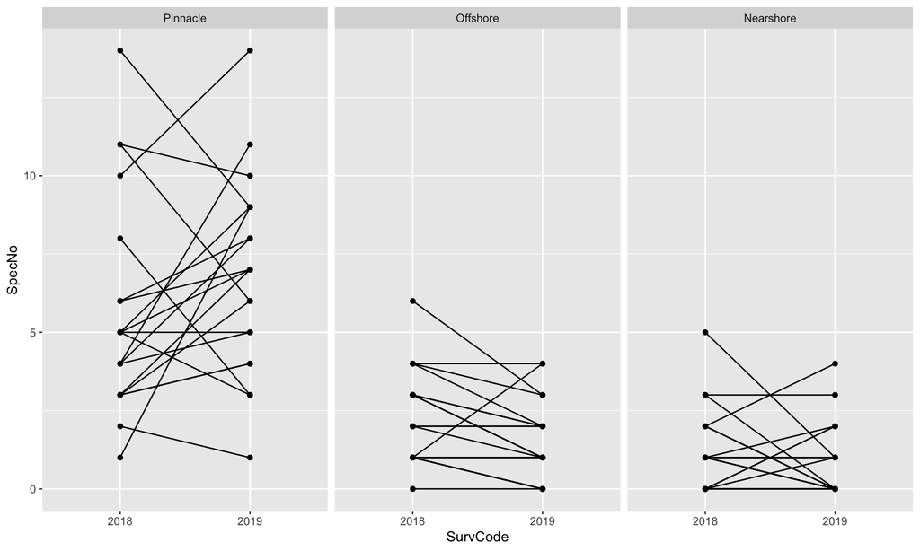

```r
# Check if random intercept/slope necessary for model
ggplot(preddiv, aes(y=SpecNo, x=SurvCode, group=Site_Tran)) +
    geom_point() +
    geom_line() +
    facet_grid(~Reeftype) # facet_wrap tried to make a square
```

# Fit model

## Poisson and Neg binom

Start with Poisson and Neg binom (Notes: REML=F returned better AIC by 5 points. ZI test good on both so no ZI term in formulae)

```r
# Poisson
prglmmp <- glmmTMB(SpecNo ~ Reeftype+(1|Site), data = preddiv, family='poisson', REML = FALSE)
# Neg binom
prglmmnb <- glmmTMB(SpecNo ~ Reeftype+(1|Site), data = preddiv, family='nbinom2', REML = FALSE)
```

## DHARMa residuals

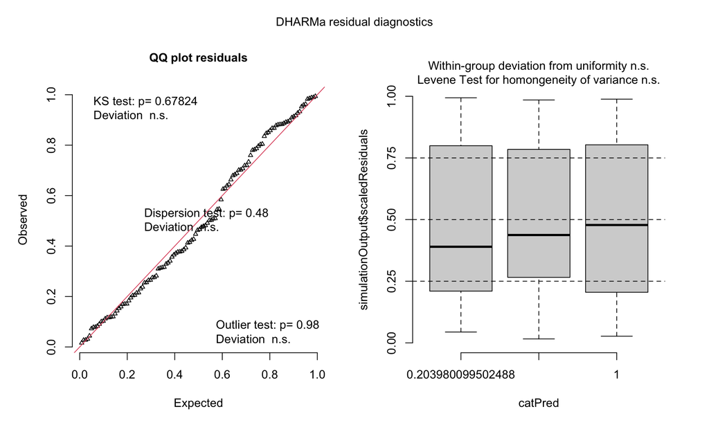

```
## Object of Class DHARMa with simulated residuals based on 250 simulations with refit = FALSE . See ?DHARMa::simulateResiduals for help.
##
## Scaled residual values: 0.8821866 0.9825618 0.8866002 0.0271374 0.9883779 0.8977422 0.9528585 0.1705379 0.9274027 0.9591828 0.8675239 0.3570103 0.9091533 0.9625922 0.9893456 0.8025751 0.6884695 0.993745 0.2544358 0.9133095 ...
```

```r
# Poisson
simulateResiduals(prglmmp, plot=T) # Looks good
```

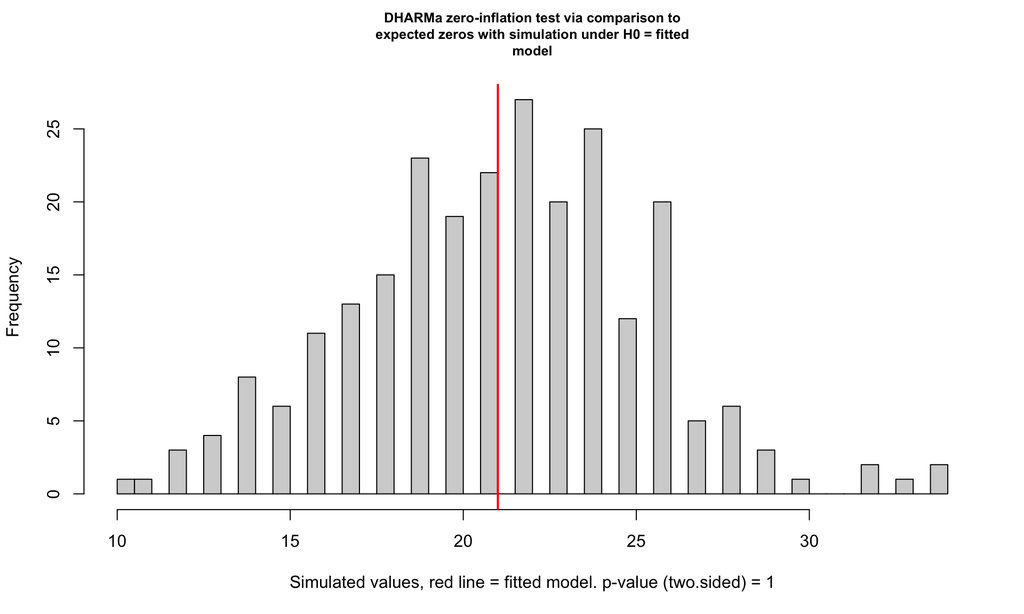

```
##
##  DHARMa zero-inflation test via comparison to expected zeros with
##  simulation under H0 = fitted model
##
## data:  simulationOutput
## ratioObsSim = 0.98758, p-value = 1
## alternative hypothesis: two.sided
```

```r
testZeroInflation(prglmmp) # No ZI
```

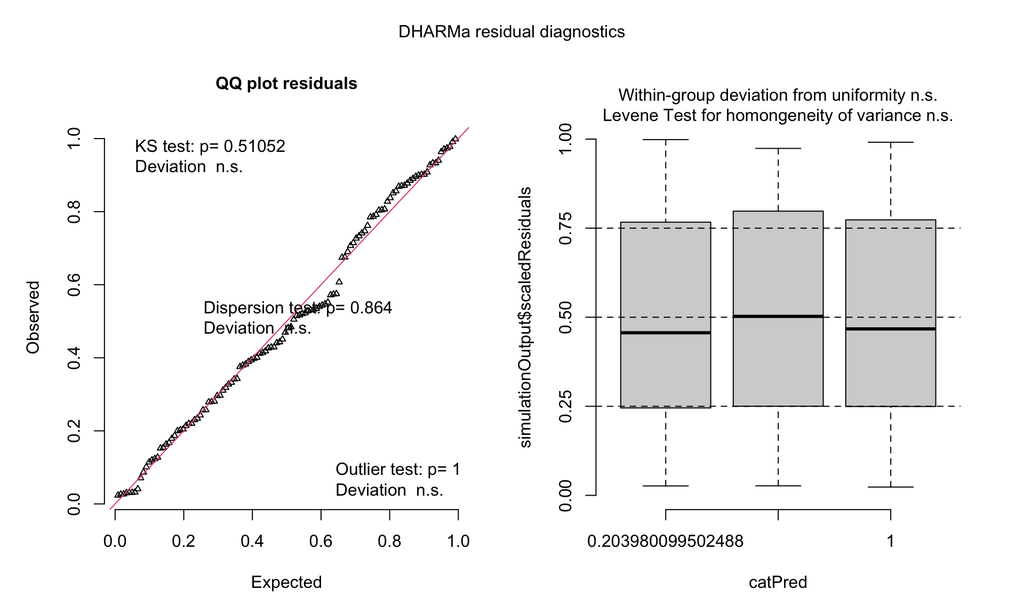

```
## Object of Class DHARMa with simulated residuals based on 250 simulations with refit = FALSE . See ?DHARMa::simulateResiduals for help.
##
## Scaled residual values: 0.8377148 0.9709774 0.785048 0.03011945 0.9911953 0.8510491 0.9017765 0.3107397 0.8689055 0.9081684 0.7147558 0.3322931 0.9637281 0.9329687 0.9778297 0.7866192 0.5349333 0.9986013 0.0310015 0.8564655 ...
```

```r
# Neg binom
simulateResiduals(prglmmnb, plot=T) # Looks good
```

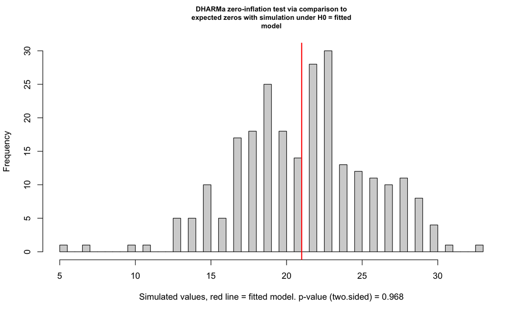

```
##
##  DHARMa zero-inflation test via comparison to expected zeros with
##  simulation under H0 = fitted model
##
## data:  simulationOutput
## ratioObsSim = 0.98351, p-value = 0.968
## alternative hypothesis: two.sided
```

```r
testZeroInflation(prglmmnb) # No ZI
```

- Residuals for both models look ok.

## AIC

```r
AIC(prglmmp, prglmmnb)
```

|  | df | AIC |
| --- | --- | --- |
| prglmmp | 4 | 454.5917 |
| prglmmnb | 5 | 455.5582 |

- Poisson best fit - now compare to random effects only

## Random effects only

```r
# RE only
prglmmREn = glmmTMB(SpecNo ~ 1 + (1|Site), data = preddiv, family='gaussian', REML = FALSE)
prglmmREp = glmmTMB(SpecNo ~ 1 + (1|Site), data = preddiv, family='poisson', REML = FALSE)
```

## AIC2

```r
AIC(prglmmp, prglmmnb, prglmmREn, prglmmREp)
```

|  | df | AIC |
| --- | --- | --- |
| prglmmp | 4 | 454.5917 |
| prglmmnb | 5 | 455.5582 |
| prglmmREn | 3 | 536.4008 |
| prglmmREp | 2 | 471.3570 |

Fixed effects a better fit than R.E. only and poisson best fit overall

# Model investigation

## Partial plot

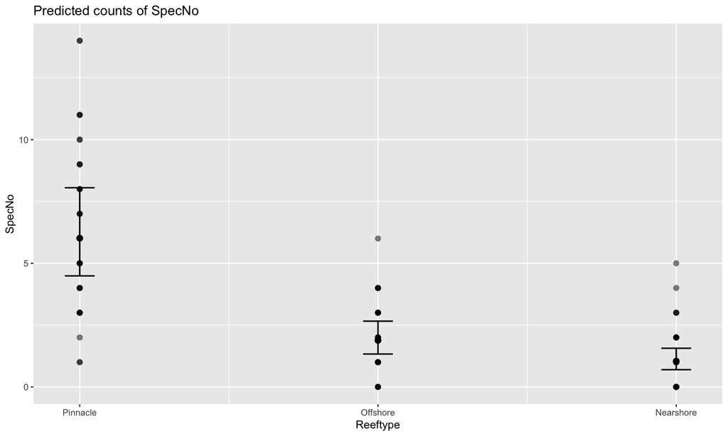

```r
prglmmp %>% plot_model(type='eff', show.data=TRUE)
```

## Summary table

```r
summary(prglmmp)
```

```
##  Family: poisson  ( log )
## Formula:          SpecNo ~ Reeftype + (1 | Site)
## Data: preddiv
##
##      AIC      BIC   logLik deviance df.resid
##    454.6    465.7   -223.3    446.6      116
##
## Random effects:
##
## Conditional model:
##  Groups Name        Variance Std.Dev.
##  Site   (Intercept) 0.07177  0.2679
## Number of obs: 120, groups:  Site, 12
##
## Conditional model:
##                   Estimate Std. Error z value Pr(>|z|)
## (Intercept)         1.7940     0.1490  12.037  < 2e-16 ***
## ReeftypeOffshore   -1.1626     0.2309  -5.034 4.80e-07 ***
## ReeftypeNearshore  -1.7514     0.2535  -6.909 4.89e-12 ***
## ---
## Signif. codes:  0 '***' 0.001 '**' 0.01 '*' 0.05 '.' 0.1 ' ' 1
```

$ Summary Interpretation $

$ Pinnacles (Intercept) $ exp(1.7940) -> mean of 6.01 spp per transect for pinnacle reefs

$ Offshore $ exp(-1.1626) = 0.3126722 0.313*6.01 -> mean of 1.88 spp per transect for offshore reefs

$ Nearshore $ exp(-1.7514) = 0.1735308 0.174*6.01 -> mean of 1.05 spp per transect for nearshore reefs

Variance in conditional model looks low but cbeck R2:

## R squared

```r
r.squaredGLMM(prglmmp) # See ML section on this glmm_example1.Rmd - hard to interpret variance of random factors in GLMM
```

```
##                 R2m       R2c
## delta     0.5762399 0.6536965
## lognormal 0.6039985 0.6851864
## trigamma  0.5429087 0.6158850
```

```r
prglmmp %>% performance::r2_nakagawa()
```

```
## # R2 for Mixed Models
##
##   Conditional R2: 0.623
##      Marginal R2: 0.549
```

-> Can also check random effects individually:

## Raneffects

```r
prglmmp %>% ranef()
```

```
## $Site
##                 (Intercept)
## Bradford Shoals  0.37771629
## Donnas           0.42888384
## Ema              0.20668431
## Hogu             0.03617716
## Inglis Shoals   -0.20714206
## Joels            0.01159016
## Kimbe Bommie    -0.16025434
## Kimbe Island    -0.08778288
## Lady Di         -0.18923818
## Madaro          -0.05966801
## Otto            -0.12016674
## Susans          -0.14530438
```

# Results

## emmeans

```r
emmeans(prglmmp, pairwise~Reeftype, transform="response") %>%
  confint() %>%
  as.data.frame() %>%
  tab_df() #tab_df for export
```

| emmeans.Reeftype | emmeans.rate | emmeans.SE | emmeans.df | emmeans.lower.CL | emmeans.upper.CL | contrasts.contrast | contrasts.estimate | contrasts.SE | contrasts.df | contrasts.lower.CL | contrasts.upper.CL |
| --- | --- | --- | --- | --- | --- | --- | --- | --- | --- | --- | --- |
| Pinnacle | 6.01 | 0.90 | 116 | 4.24 | 7.79 | Pinnacle - Offshore | 4.13 | 0.96 | 116 | 1.87 | 6.40 |
| Offshore | 1.88 | 0.33 | 116 | 1.22 | 2.54 | Pinnacle - Nearshore | 4.97 | 0.92 | 116 | 2.79 | 7.16 |
| Nearshore | 1.04 | 0.22 | 116 | 0.62 | 1.47 | Offshore - Nearshore | 0.84 | 0.39 | 116 | -0.10 | 1.77 |

```r
# OR from ML2021:
prglmmnb %>%
  emmeans(~Reeftype) %>%
  regrid %>%
  pairs() %>%
  summary(infer=TRUE)
```

|  | contrast | estimate | SE | df | lower.CL | upper.CL | t.ratio | p.value |
| --- | --- | --- | --- | --- | --- | --- | --- | --- |
| 1 | Pinnacle - Offshore | 4.141549 | 0.9572987 | 115 | 1.8684980 | 6.414599 | 4.326287 | 9.581134e-05 |
| 2 | Pinnacle - Nearshore | 4.979825 | 0.9223045 | 115 | 2.7898656 | 7.169784 | 5.399328 | 1.088860e-06 |
| 3 | Offshore - Nearshore | 0.838276 | 0.3953934 | 115 | -0.1005628 | 1.777115 | 2.120106 | 9.022460e-02 |

$ emmeans notes $ - “Rate” is the reported term for a Poisson model (it’s “response” for nb) - Results from neg binom very similar

## Contrasts

```r
# Need to convert to a tibble in the process to change the names of the contrasts (for plotting later):
richcontrasts <- emmeans(prglmmp, pairwise ~ Reeftype, transform='response') %>%
  confint() %>%
  as.data.frame()

# pvalues
richpvals <- emmeans(prglmmp,  ~ Reeftype, transform='response', combine=TRUE) %>%
  pairs() %>%
  as.data.frame()

# Combine for full results table
richresults <- bind_cols(richcontrasts, richpvals[5:6])

# Write to csv
write_csv(richresults, file = "../../output/rtables/richresults.csv")

# Copy to html
richresults %>%
  tab_df(file="../../output/rtables/richresults.html", title = "Species richness contrasts (estimates)") #%>%
```

Species richness contrasts (estimates)

| emmeans.Reeftype | emmeans.rate | emmeans.SE | emmeans.df | emmeans.lower.CL | emmeans.upper.CL | contrasts.contrast | contrasts.estimate | contrasts.SE | contrasts.df | contrasts.lower.CL | contrasts.upper.CL | t.ratio | p.value |
| --- | --- | --- | --- | --- | --- | --- | --- | --- | --- | --- | --- | --- | --- |
| Pinnacle | 6.01 | 0.90 | 116 | 4.24 | 7.79 | Pinnacle - Offshore | 4.13 | 0.96 | 116 | 1.87 | 6.40 | 4.33 | 0.00 |
| Offshore | 1.88 | 0.33 | 116 | 1.22 | 2.54 | Pinnacle - Nearshore | 4.97 | 0.92 | 116 | 2.79 | 7.16 | 5.40 | 0.00 |
| Nearshore | 1.04 | 0.22 | 116 | 0.62 | 1.47 | Offshore - Nearshore | 0.84 | 0.39 | 116 | -0.10 | 1.77 | 2.12 | 0.09 |

```r
# Display inline
richresults
```

| emmeans.Reeftype | emmeans.rate | emmeans.SE | emmeans.df | emmeans.lower.CL | emmeans.upper.CL | contrasts.contrast | contrasts.estimate | contrasts.SE | contrasts.df | contrasts.lower.CL | contrasts.upper.CL | t.ratio | p.value |
| --- | --- | --- | --- | --- | --- | --- | --- | --- | --- | --- | --- | --- | --- |
| Pinnacle | 6.013746 | 0.8963253 | 116 | 4.2384611 | 7.789032 | Pinnacle - Offshore | 4.133420 | 0.9552196 | 116 | 1.8655621 | 6.401278 | 4.327194 | 9.491437e-05 |
| Offshore | 1.880326 | 0.3323964 | 116 | 1.2219731 | 2.538679 | Pinnacle - Nearshore | 4.970167 | 0.9202794 | 116 | 2.7852633 | 7.155071 | 5.400716 | 1.068632e-06 |
| Nearshore | 1.043579 | 0.2151092 | 116 | 0.6175282 | 1.469630 | Offshore - Nearshore | 0.836747 | 0.3945799 | 116 | -0.1000547 | 1.773549 | 2.120602 | 9.008783e-02 |

## Ratios

```r
richratios <- emmeans(prglmmp, pairwise ~ Reeftype, type='response') %>%
  confint() %>%
  as.data.frame()

# p values
richratiospvals <- emmeans(prglmmp,  ~ Reeftype, type='response', combine=TRUE) %>%
  pairs() %>%
  as.data.frame()

# Combine
richratios <- bind_cols(richratios, richratiospvals[6:7])

# Write to csv
write_csv(richratios, file = "../../output/rtables/richratios.csv")

# Copy to html
richratios %>%
  tab_df(file="../../output/rtables/richratios.html", title = "Abundance contrasts (ratios)")
```

Abundance contrasts (ratios)

| emmeans.Reeftype | emmeans.rate | emmeans.SE | emmeans.df | emmeans.lower.CL | emmeans.upper.CL | contrasts.contrast | contrasts.ratio | contrasts.SE | contrasts.df | contrasts.lower.CL | contrasts.upper.CL | t.ratio | p.value |
| --- | --- | --- | --- | --- | --- | --- | --- | --- | --- | --- | --- | --- | --- |
| Pinnacle | 6.01 | 0.90 | 116 | 4.48 | 8.08 | Pinnacle / Offshore | 3.20 | 0.74 | 116 | 1.85 | 5.53 | 5.03 | 0.00 |
| Offshore | 1.88 | 0.33 | 116 | 1.32 | 2.67 | Pinnacle / Nearshore | 5.76 | 1.46 | 116 | 3.16 | 10.52 | 6.91 | 0.00 |
| Nearshore | 1.04 | 0.22 | 116 | 0.69 | 1.57 | Offshore / Nearshore | 1.80 | 0.49 | 116 | 0.95 | 3.43 | 2.18 | 0.08 |

```r
richratios
```

| emmeans.Reeftype | emmeans.rate | emmeans.SE | emmeans.df | emmeans.lower.CL | emmeans.upper.CL | contrasts.contrast | contrasts.ratio | contrasts.SE | contrasts.df | contrasts.lower.CL | contrasts.upper.CL | t.ratio | p.value |
| --- | --- | --- | --- | --- | --- | --- | --- | --- | --- | --- | --- | --- | --- |
| Pinnacle | 6.013746 | 0.8963253 | 116 | 4.4765083 | 8.078874 | Pinnacle / Offshore | 3.198246 | 0.7386284 | 116 | 1.8483474 | 5.534014 | 5.034047 | 5.288693e-06 |
| Offshore | 1.880326 | 0.3323964 | 116 | 1.3248751 | 2.668649 | Pinnacle / Nearshore | 5.762617 | 1.4608378 | 116 | 3.1567166 | 10.519713 | 6.908775 | 8.387404e-10 |
| Nearshore | 1.043579 | 0.2151092 | 116 | 0.6937781 | 1.569749 | Offshore / Nearshore | 1.801805 | 0.4874693 | 116 | 0.9478757 | 3.425029 | 2.176308 | 7.955658e-02 |

## Data for plotting

```r
richplotdata <- emmeans(prglmmp, pairwise ~ Reeftype, transform='response') %>%
  confint() %>%
  as_tibble()

#save(richplotdata, file='../../data/richplotdata.RData')
```

# 2. Shannon H’ Diversity

# Basic data exploration

## Data overview

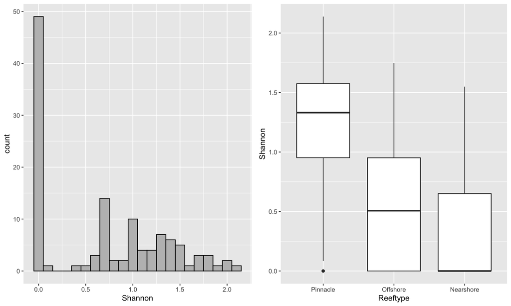

```r
# Shannon
shhist <- ggplot(preddiv, aes(x=Shannon)) +
  geom_histogram(binwidth=0.1, color="black", fill="grey") # Possibly bimodal??
# Simpson - not used, see notes elsewhere
#sihist <- ggplot(data=subset(preddiv, Reeftype=='Nearshore'), aes(x=Simpson)) +
#  geom_histogram(binwidth=0.1, color="black", fill="grey") # No idea...

shbox <- ggplot(preddiv, aes(x=Reeftype, y=Shannon))+
  geom_boxplot()

# Plot together
grid.arrange(shhist, shbox, ncol=2)
```

## Random effects

- Investigate random effects (added post ML course Oct 2021) (Note: AIC comparison with fixed effect models included below)

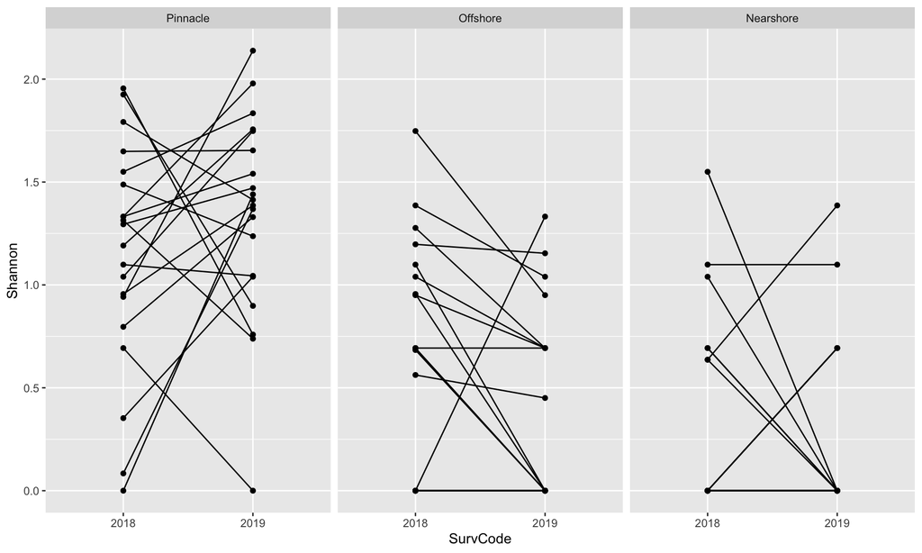

```r
# Check if random intercept/slope necessary for model
ggplot(preddiv, aes(y=Shannon, x=SurvCode, group=Site_Tran)) +
    geom_point() +
    geom_line() +
    facet_grid(~Reeftype) # facet_wrap tried to make a square
```

-> A note on error distributions - Looks like it might be very zero-inflated so likely will need a ZI term to handle - Can’t use Poisson or Neg Binom as these are not count data - In addition most error distributions won’t work with these data including: - Gamma - has to be positive values (and very bad residuals when using on raw data + 0.0000001) - ziGamma - same - Beta - has to be 0 < y < 1 - Binom - y values must be 0 <= y <= 1 - Inverse gaussian - positive values only and wouldn’t work on ShannonAdj - All quasi families - All truncated families So.. two remaining candidates are gaussian and tweedie

# Fit model

Will use gaussian and tweedie distributions and check.

## Gaussian and Tweedie

```r
# Gaussian (trying post ML2021)
pshan.glmm <- glmmTMB(Shannon ~ Reeftype+(1|Site), data = preddiv, family=gaussian(link = 'identity'), ziformula = ~0,  REML = TRUE)
pshan.glmmT <- glmmTMB(Shannon ~ Reeftype+(1|Site), data = preddiv, family=tweedie(link = 'log'), ziformula = ~0, REML = FALSE)
```

## DHARMa residuals

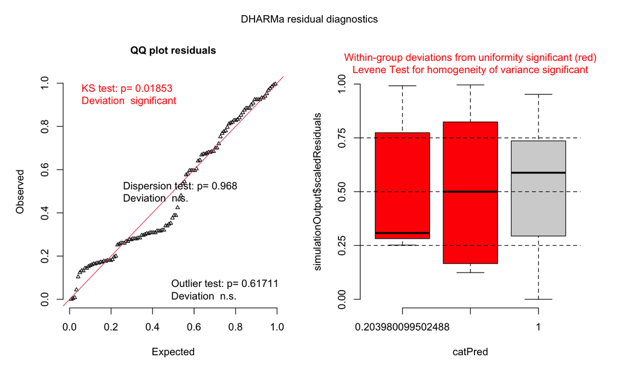

```
## Object of Class DHARMa with simulated residuals based on 250 simulations with refit = FALSE . See ?DHARMa::simulateResiduals for help.
##
## Scaled residual values: 0.176 0.924 0.684 0 0.58 0.008 0.684 0.596 0.852 0.48 0.832 0.3 0.932 0.976 0.984 0.768 0.256 0.992 0.34 0.7 ...
```

```r
simulateResiduals(pshan.glmm, plot=TRUE) # Fails deviation and hv and QQ plot looks bad.
```

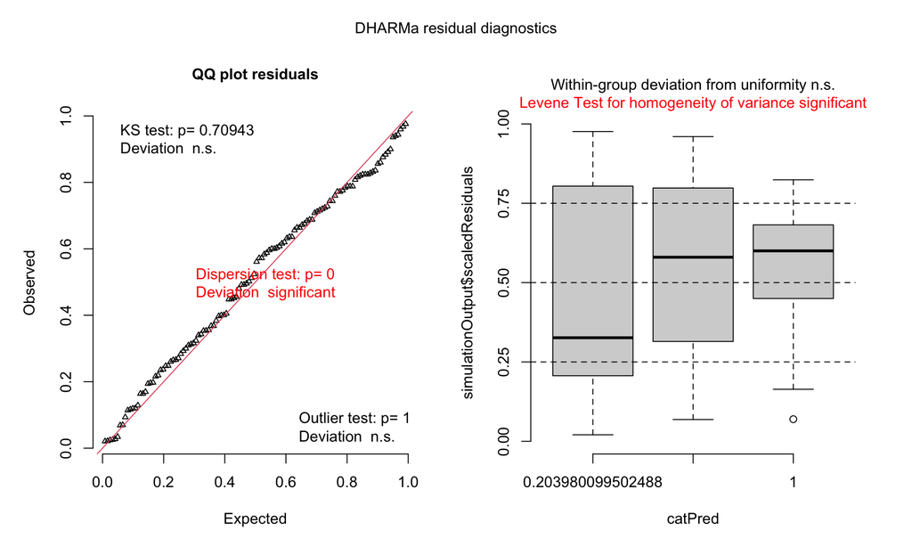

```
## Object of Class DHARMa with simulated residuals based on 250 simulations with refit = FALSE . See ?DHARMa::simulateResiduals for help.
##
## Scaled residual values: 0.368 0.744 0.616 0.06971595 0.62 0.164 0.672 0.632 0.728 0.496 0.824 0.2650959 0.94 0.944 0.968 0.836 0.02149854 0.976 0.561183 0.772 ...
```

```r
simulateResiduals(pshan.glmmT, plot=TRUE) # Fails dispersion and hv but QQ plot looks good. Check ZI...
```

## ZI test

-> Discarded the gaussian model so just for tweedie

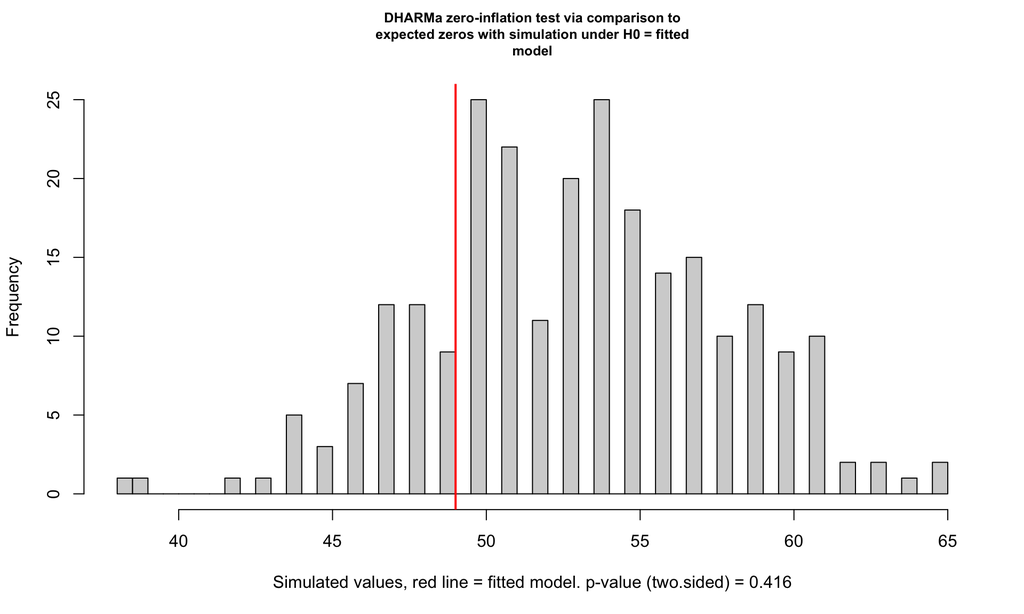

```
##
##  DHARMa zero-inflation test via comparison to expected zeros with
##  simulation under H0 = fitted model
##
## data:  simulationOutput
## ratioObsSim = 0.92209, p-value = 0.416
## alternative hypothesis: two.sided
```

```r
testZeroInflation(pshan.glmmT)
```

-> Slightly under-dispersed

## Random effects only

```r
pshan.glmmRE = glmmTMB(Shannon ~ 1 + (1|Site), data = preddiv, family='tweedie', REML = FALSE)
```

## AIC

```r
AIC(pshan.glmmT, pshan.glmmRE)
```

|  | df | AIC |
| --- | --- | --- |
| pshan.glmmT | 6 | 248.7711 |
| pshan.glmmRE | 4 | 261.5676 |

-> Full model outperforms RE-only model

# Model investigation

## Partial plot

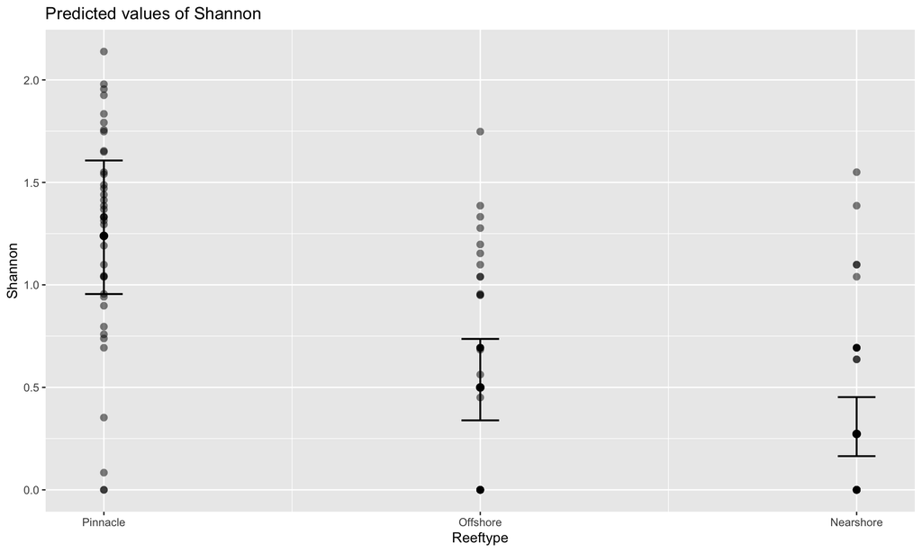

```r
pshan.glmmT %>% plot_model(type='eff', show.data=TRUE)
```

## Summary table

```r
summary(pshan.glmmT)
```

```
##  Family: tweedie  ( log )
## Formula:          Shannon ~ Reeftype + (1 | Site)
## Data: preddiv
##
##      AIC      BIC   logLik deviance df.resid
##    248.8    265.5   -118.4    236.8      114
##
## Random effects:
##
## Conditional model:
##  Groups Name        Variance  Std.Dev.
##  Site   (Intercept) 8.102e-10 2.846e-05
## Number of obs: 120, groups:  Site, 12
##
## Dispersion parameter for tweedie family (): 0.833
##
## Conditional model:
##                   Estimate Std. Error z value Pr(>|z|)
## (Intercept)         0.2143     0.1313   1.632 0.102621
## ReeftypeOffshore   -0.9082     0.2357  -3.853 0.000117 ***
## ReeftypeNearshore  -1.5133     0.2873  -5.268 1.38e-07 ***
## ---
## Signif. codes:  0 '***' 0.001 '**' 0.01 '*' 0.05 '.' 0.1 ' ' 1
```

$ Summary Interpretation $

$ Pinnacles (Intercept) $ exp(0.2143) = 1.238994 -> mean of 1.24 spp per transect for pinnacle reefs

$ Offshore $ exp(-0.9082) = 0.4032494 0.4*1.24 = 0.496 -> mean of 0.5 spp per transect for offshore reefs

Variance in conditional model very low

## Raneffects

```r
pshan.glmmT %>% ranef()
```

```
## $Site
##                   (Intercept)
## Bradford Shoals -9.138342e-10
## Donnas           4.971262e-09
## Ema              2.277362e-09
## Hogu             1.441767e-09
## Inglis Shoals   -9.755634e-11
## Joels            2.728192e-10
## Kimbe Bommie     7.385713e-10
## Kimbe Island    -1.786520e-09
## Lady Di         -1.919832e-09
## Madaro          -1.525715e-09
## Otto            -1.932608e-09
## Susans          -1.525715e-09
```

# Results

## emmeans

Calculate estimated marginal means of Shannon diversity index per reef type:

```r
emmeans(pshan.glmmT, ~Reeftype, transform="response") %>%
  #confint() #%>%
  as.tibble() #%>%
```

| Reeftype | response | SE | df | lower.CL | upper.CL |
| --- | --- | --- | --- | --- | --- |
| Pinnacle | 1.2390003 | 0.16267055 | 114 | 0.9167512 | 1.5612494 |
| Offshore | 0.4996068 | 0.09782012 | 114 | 0.3058259 | 0.6933877 |
| Nearshore | 0.2727957 | 0.06970602 | 114 | 0.1347087 | 0.4108828 |

```r
  #tab_df() #tab_df for HTML export
```

## Contrasts

Calculate pairwise contrasts between reef types (including 95% CI and Pvals)

```r
pshan.glmmT %>%
  emmeans(~Reeftype) %>%
  regrid %>%
  pairs() %>%
  summary(infer=TRUE)
```

|  | contrast | estimate | SE | df | lower.CL | upper.CL | t.ratio | p.value |
| --- | --- | --- | --- | --- | --- | --- | --- | --- |
| 1 | Pinnacle - Offshore | 0.7393936 | 0.1898170 | 114 | 0.28863231 | 1.1901548 | 3.895297 | 4.838037e-04 |
| 2 | Pinnacle - Nearshore | 0.9662046 | 0.1769764 | 114 | 0.54593610 | 1.3864731 | 5.459512 | 8.440376e-07 |
| 3 | Offshore - Nearshore | 0.2268110 | 0.1201154 | 114 | -0.05842879 | 0.5120508 | 1.888276 | 1.467213e-01 |

## Ratios

Calculate pairwise contrasts on ratio scale (inc 95% CI and Pvals)

```r
pshan.glmmT %>%
  emmeans(~Reeftype, type='response') %>%
  pairs() %>%
  summary(infer=TRUE)
```

|  | contrast | ratio | SE | df | lower.CL | upper.CL | null | t.ratio | p.value |
| --- | --- | --- | --- | --- | --- | --- | --- | --- | --- |
| 1 | Pinnacle / Offshore | 2.479951 | 0.5846213 | 114 | 1.4168353 | 4.340771 | 1 | 3.852729 | 5.637517e-04 |
| 2 | Pinnacle / Nearshore | 4.541861 | 1.3047901 | 114 | 2.2959034 | 8.984916 | 1 | 5.267794 | 1.967566e-06 |
| 3 | Offshore / Nearshore | 1.831432 | 0.5895622 | 114 | 0.8526941 | 3.933582 | 1 | 1.879692 | 1.492385e-01 |

```r
# Ratios with CI
#emmeans(pshan.glmmT, pairwise ~ Reeftype, type='response') %>%
#  confint() %>%
#  as.data.frame()

# p values
#shanratiopvals <- emmeans(pshan.glmmT,  ~ Reeftype, type='response', combine=TRUE) %>%
#  pairs() %>%
#  as.data.frame()

# Combine
#shanratios <- bind_cols(shanratios, shanratiopvals[6:7])

# Write to csv
#write_csv(shanratios, file = "../../output/rtables/shanratios.csv")

# Copy to html
#shanratios %>%
#  tab_df(file="../../output/rtables/shanratios.html", title = "shandance contrasts (ratios)")
#shanratios
```

## Plot data

```r
shanplotdata <- emmeans(pshan.glmmT, pairwise ~ Reeftype, transform='response') %>%
  confint() %>%
  as_tibble()


#save(shanplotdata, file='../../data/shanplotdata.RData')
```

# Community differences

```r
#getwd()
#source("pred_mvabund.R", local = knitr::knit_global())
```